# Final Project on Loneliness

Frederikke Hæsum

12/11/2020

# Goal

I want to be able to analyse my own dataset that I created via Google Forms and cleaned up using OpenRefine. I will therefore focus mainly on creating visuals by using RStudio.

# Getting set up

First, I will create a few subdirectories where I can store my visuals and, potentially, any altered data.

```r
dir.create("data")
dir.create("data_output")
```

```r
dir.create("fig_output")
```

Now, I will load tidyverse, which contains a number of packages that I will need for my analysis.

```r
library("tidyverse")
```

# Loading the data

Next I am going to load my dataset by using the function read_csv

```r
responses <- read_csv("data/Loneliness-clean-data.csv.csv")
```

I check the content of my data by using the view function, head function, or by simply typing the name of the data frame - responses - in the console:

```r
view(responses)
head(responses)
```

```
## # A tibble: 6 x 13
##   Tidsstempel respondent_gend… respondent_age respondent_occu… marital_status
##   <chr>       <chr>            <chr>          <chr>            <chr>
## 1 2020/11/30… Female           25-35          Student          Single
## 2 2020/11/30… Male             15-25          Student          Single
## 3 2020/11/30… Female           25-35          Student          Cohabitant/Fa…
## 4 2020/11/30… Female           15-25          Student          Cohabitant/Fa…
## 5 2020/11/30… Female           25-35          Working          Single
## 6 2020/11/30… Female           25-35          Working          Single
## # … with 8 more variables: infected_with_covid <chr>, company_importance <chr>,
## #   influence_on_social_life <chr>, lack_of_company <chr>,
## #   most_lonely_period <chr>, feeling_lonely_time <chr>,
## #   feeling_lonely_extent <chr>, feeling_lonely_before_pandemic <chr>
```

```r
responses
```

```
## # A tibble: 137 x 13
##    Tidsstempel respondent_gend… respondent_age respondent_occu… marital_status
##    <chr>       <chr>            <chr>          <chr>            <chr>
##  1 2020/11/30… Female           25-35          Student          Single
##  2 2020/11/30… Male             15-25          Student          Single
##  3 2020/11/30… Female           25-35          Student          Cohabitant/Fa…
##  4 2020/11/30… Female           15-25          Student          Cohabitant/Fa…
##  5 2020/11/30… Female           25-35          Working          Single
##  6 2020/11/30… Female           25-35          Working          Single
##  7 2020/11/30… Female           15-25          Student          Single
##  8 2020/11/30… Male             25-35          Student          Single
##  9 2020/11/30… Male             25-35          Student          Cohabitant/Fa…
## 10 2020/11/30… Female           15-25          Working          Single
## # … with 127 more rows, and 8 more variables: infected_with_covid <chr>,
## #   company_importance <chr>, influence_on_social_life <chr>,
## #   lack_of_company <chr>, most_lonely_period <chr>, feeling_lonely_time <chr>,
## #   feeling_lonely_extent <chr>, feeling_lonely_before_pandemic <chr>
```

# Analysing my data

Now that I am happy with the data that has been loaded correctly, I will move on to analyse the data via visualisations.

The respondents were asked whether they had been infected with COVID-19 or not. In order to see how the answers are distributed. I will do this by using plot function:

```r
## create a vector from the data frame column "infected_with_covid"
infected_with_covid <- responses$infected_with_covid
## convert it into a factor
infected_with_covid <- as.factor(infected_with_covid)
## let's see what it looks like
infected_with_covid
```

```
##   [1] Yes No  No  No  No  No  No  No  No  Yes No  No  No  No  No  No  No  No
##  [19] No  No  No  No  No  No  No  No  No  No  No  No  No  No  No  No  No  No
##  [37] No  No  No  No  No  No  No  No  No  No  No  No  No  No  No  No  No  No
##  [55] No  No  No  No  No  No  No  No  No  Yes No  No  No  No  No  No  No  No
##  [73] No  No  No  No  Yes No  No  No  No  Yes No  No  No  No  No  No  No  No
##  [91] No  No  Yes No  No  Yes No  No  No  No  No  No  Yes No  No  No  No  No
## [109] No  No  No  No  No  No  No  No  No  No  No  No  No  No  No  No  No  No
## [127] No  No  No  No  No  No  No  No  No  No  No
## Levels: No Yes
```

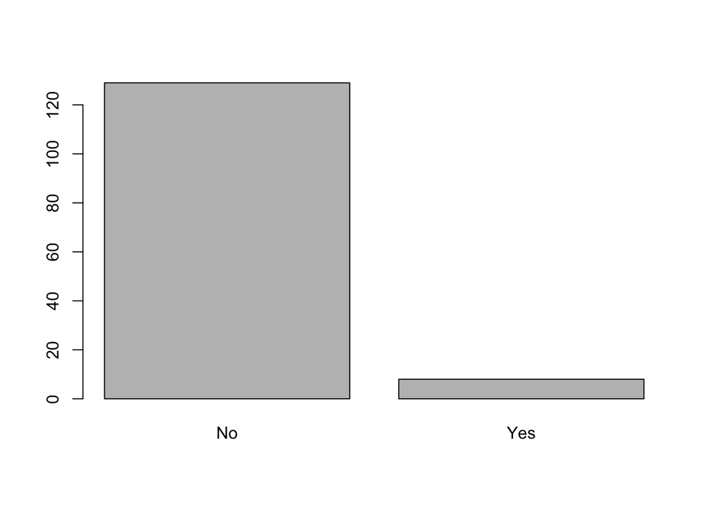

```r
plot(infected_with_covid)
```

In order to make a proper visualisation I will need the ggplot2 package - it is already installed in the tidyverse package.

## Infected with COVID-19

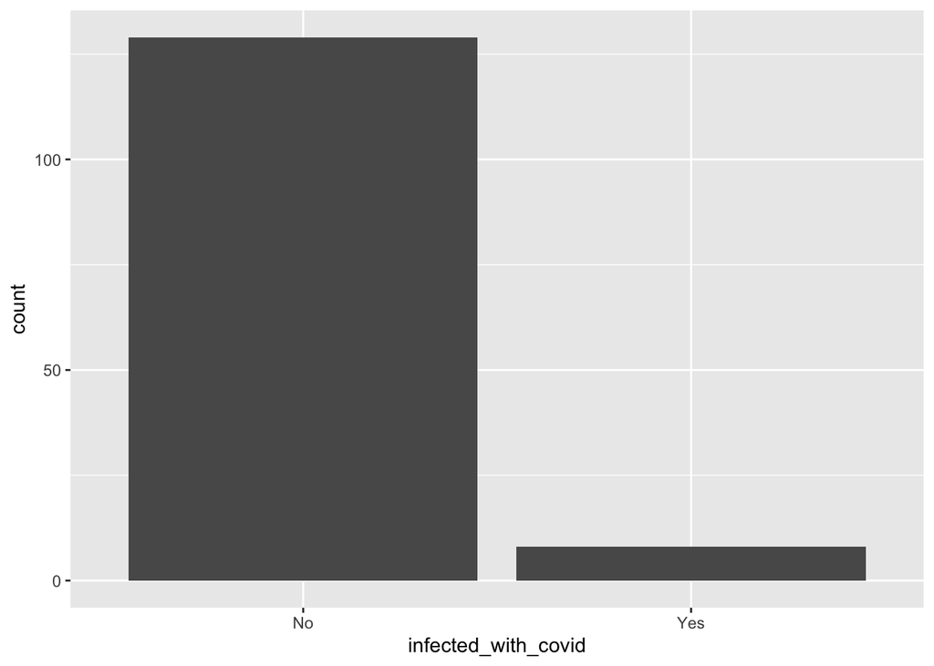

```r
responses %>%
    ggplot(aes(x = infected_with_covid)) +
    geom_bar()
```

This shows a vast amount of people not being infected at any point.

I will save this visual for later use:

```r
visual_1 <- responses %>%
  ggplot(aes(x = infected_with_covid)) +
    geom_bar() +
  labs(title = "Infected with COVID-19",
       x = "Yes or no",
       y = "Amount of respondents")
ggsave("fig_output/infectedwithcovid.png", visual_1, dpi = 500)
```

The visual will now be located in the fig_ouput directory.

## Tendencies relating to loneliness during the pandemic

I want to look at how the different groups of respondents in terms of age, gender, and occupation have distributed their answers:

First, I will see how the different age groups are divided - I will use the same plot function as before:

```r
respondent_age <- responses$respondent_age
respondent_age <- as.factor(respondent_age)
respondent_age
```

```
##   [1] 25-35 15-25 25-35 15-25 25-35 25-35 15-25 25-35 25-35 15-25 15-25 25-35
##  [13] 25-35 15-25 15-25 15-25 15-25 15-25 25-35 15-25 25-35 15-25 15-25 15-25
##  [25] 15-25 15-25 15-25 15-25 15-25 15-25 15-25 25-35 15-25 45-60 15-25 15-25
##  [37] 15-25 60-80 15-25 25-35 15-25 15-25 15-25 15-25 25-35 25-35 25-35 15-25
##  [49] 15-25 25-35 15-25 45-60 25-35 25-35 15-25 25-35 15-25 15-25 60-80 15-25
##  [61] 15-25 25-35 15-25 15-25 15-25 15-25 15-25 15-25 15-25 25-35 25-35 25-35
##  [73] 15-25 15-25 15-25 25-35 15-25 25-35 15-25 15-25 15-25 25-35 15-25 15-25
##  [85] 15-25 25-35 35-45 15-25 15-25 25-35 25-35 15-25 15-25 15-25 15-25 15-25
##  [97] 15-25 35-45 35-45 15-25 35-45 25-35 45-60 45-60 15-25 60-80 25-35 25-35
## [109] 25-35 15-25 25-35 15-25 25-35 25-35 15-25 15-25 25-35 15-25 15-25 25-35
## [121] 25-35 15-25 15-25 15-25 15-25 25-35 25-35 15-25 25-35 15-25 15-25 35-45
## [133] 25-35 25-35 35-45 60-80 25-35
## Levels: 15-25 25-35 35-45 45-60 60-80
```

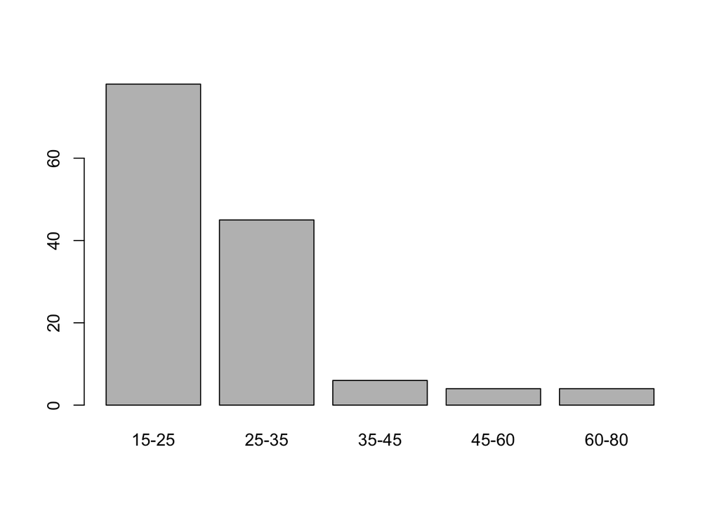

```r
plot(respondent_age)
```

This shows me that the majority of the respondents are situated in the age groups 15-25 and 25-35.

However, I will create a visual that illustrates how each individual age group have answered the question of influence on their social life. I will also put gender into the visual:

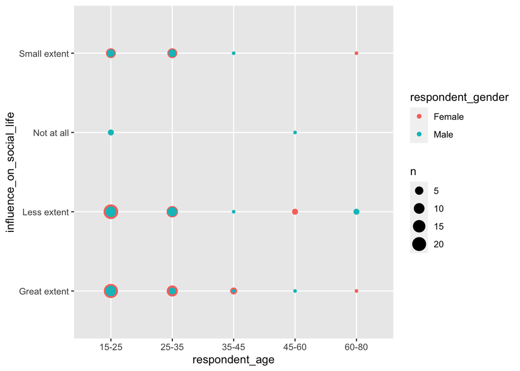

```r
responses %>%
   ggplot(aes(x = respondent_age , y = influence_on_social_life, color = respondent_gender)) +
   geom_count()
```

I am saving the visual:

```r
visual_2 <- responses %>%
  ggplot(aes(x = respondent_age , y = influence_on_social_life, color = respondent_gender)) +
   geom_count() +
  labs(title =  "Influence on social life", x = "Respondent age",
       y = "Impact on social life")

ggsave("fig_output/impactonsociallife.png", visual_2, dpi = 500)
```

## Comparison of before and during the pandemic

Now, I want to make a visual that can show me, whether or not the respondents felt more lonely before or during the pandemic:

I want to create the plot showing the difference between before and during the pandemic:

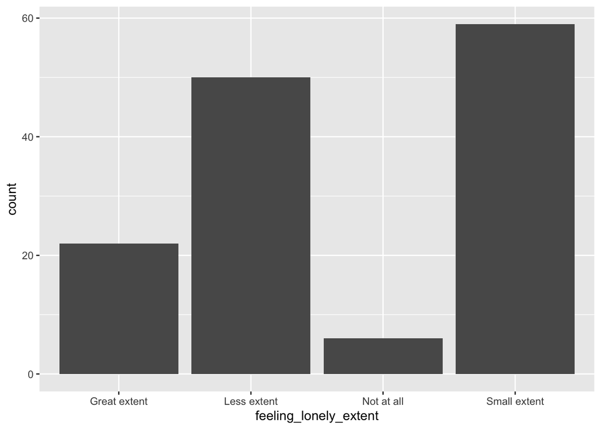

```r
responses %>%
  ggplot(aes(x = feeling_lonely_extent)) +
  geom_bar()
```

This shows the feeling of loneliness during the pandemic - I want to see what the respondents answered in terms of before the pandemic:

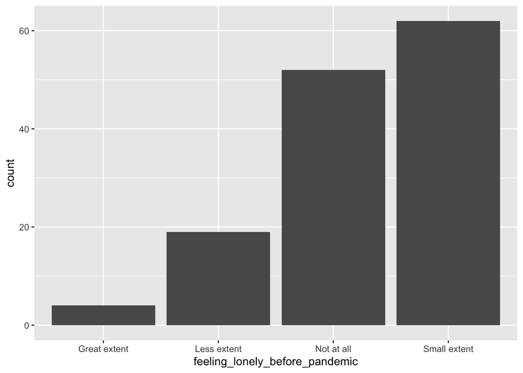

```r
responses %>%
  ggplot(aes(x = feeling_lonely_before_pandemic)) +
    geom_bar()
```

I am saving the two visuals for later use:

```r
visual_3 <- responses %>%
  ggplot(aes(x = feeling_lonely_extent)) +
  geom_bar() +
  labs(title =  "Feeling lonely during pandeic", x = "Extent",
       y = "Amount of respondents")

ggsave("fig_output/feelinglonelyduringpandemic.png", visual_3, dpi = 500)
visual_4 <- responses %>%
  ggplot(aes(x = feeling_lonely_before_pandemic)) +
  geom_bar() +
  labs(title =  "Feeling lonely before pandeic", x = "Extent",
       y = "Amount of respondents")

ggsave("fig_output/feelinglonelybeforepandemic.png", visual_4, dpi = 500)
```

Lastly, I want to make a visual that shows what the individual occupation groups have answered as well as marital status.

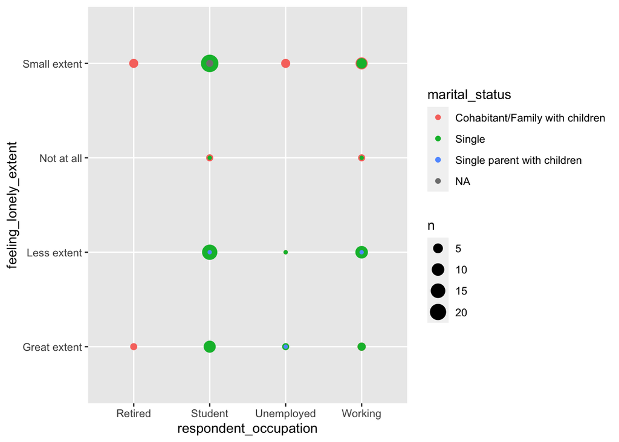

```r
responses %>%
   ggplot(aes(x = respondent_occupation , y = feeling_lonely_extent, color = marital_status)) +
   geom_count()
```

I am saving the visual:

```r
visual_5 <- responses %>%
   ggplot(aes(x = respondent_occupation , y = feeling_lonely_extent, color = marital_status)) +
   geom_count() +
  labs(title =  "Respondents marital status and occupation", x = "Occupation",
       y = "Extent of loneliness")
ggsave("fig_output/respondentsmaritalstatus_and_occupation.png", visual_5, dpi = 500)
```